# Density estimation: Bandwidth choice by leave-one-out maximum likelihood

Louis Van Langendonck

2023-09-23

## Histogram

#### 1.

Consider the kernel density estimator at $x_i$ using all the observations :
$$\hat{f}_{hist}(x_i) = \frac{1}{nb} \sum_{k=1}^n
I_{B_{j\left(x_k\right)}}(x_i)$$
. Which can be rewritten as:
$$\hat{f}_{hist}(x_i) = \frac{1}{nb} \left(1 + \sum_{k \neq i}^n
I_{B_{j\left(x_k\right)}}(x_i) \right)$$
. Now consider the expression for the leave-one-out likelihood of observation $x_i$ (so computed by all other elements in the sample):
$$\hat{f}_{hist, (-i)}(x_i) =
\frac{1}{(n-1)b} \sum_{k \neq i}^n I_{B_{j\left(x_k\right)}}(x_i)$$
, which can then be rewritten using the previously derived formula for $\hat{f}_{hist}(x_i)$ to the final expression:
$$\hat{f}_{hist,
(-i)}(x_i) = \left(\frac{n}{n-1}\right) \left( \hat{f}_{hist}(x_i) -
\frac{1}{nb} \right)$$
.

#### 2-3.

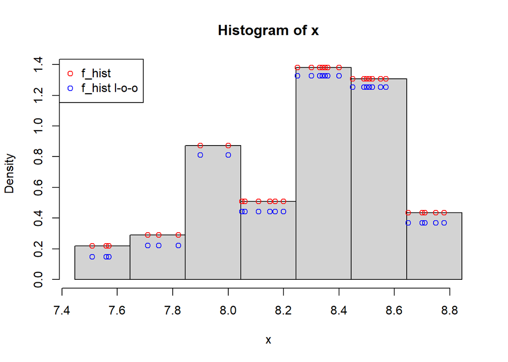

```r
cdrate.df <- read.table("cdrate.dat")
x <- cdrate.df[,1]

A <- min(x)-.05*diff(range(x))
Z <- max(x)+.05*diff(range(x))
nbr <- 7

hx <- hist(x,breaks=seq(A,Z,length=nbr+1),freq=F)
binwidth <- hx$breaks[2]-hx$breaks[1]
hx_f <- stepfun(hx$breaks,c(0,hx$density,0))
y_hist <- hx_f(x)
points(x,y_hist,col="red", pch=1)

y_loo_hist <- (y_hist-(1/(length(x)*binwidth)))*(length(x)/(length(x)-1))
points(x,y_loo_hist,col="blue", pch=1)

par(xpd=TRUE)
legend( x="topleft",
        legend=c(expression("f_hist"),"f_hist l-o-o"),
        col=c("red","blue"), pch=c(1,1))
```

#### 4.

The sample log-likelihood function is calculated using $l_{C V}(b)=\sum_{i=1}^n \log \hat{f}_{hist,(-i)}\left(x_i\right)$.

```r
loo_log_likelihood <- sum(log(y_loo_hist))
```

If we apply this to our data and estimators (where the binsize b is equal to 0.1995714), the result is $l_{C V}(b)=$-16.5843186.

#### 5.

```r
nbr_seq <- seq(1,15)
nbr_loo_log_likelihood <- c()
for (nbr in nbr_seq) {
  hx <- hist(x,breaks=seq(A,Z,length=nbr+1),plot=F)
  binwidth <- hx$breaks[2]-hx$breaks[1]
  hx_f <- stepfun(hx$breaks,c(0,hx$density,0))
  y_hist <- hx_f(x)
  y_loo_hist <- (y_hist-(1/(length(x)*binwidth)))*(length(x)/(length(x)-1))
  if (any(y_loo_hist==0)) {
    nbr_loo_log_likelihood <- c(nbr_loo_log_likelihood,-Inf)
  }
  else {
    nbr_loo_log_likelihood <- c(nbr_loo_log_likelihood,sum(log(y_loo_hist)))
  }
}
```

Some of these log likelihoods will give -inf values. This happens when an observation has a leave-one-out likelihood of zero of which the log cannot be calculated.

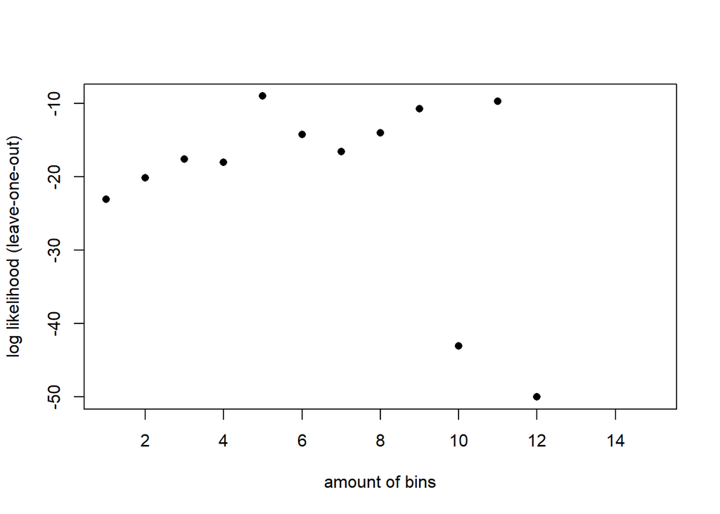

```r
plot(nbr_seq,nbr_loo_log_likelihood, pch=16, xlab='amount of bins', ylab = 'log likelihood (leave-one-out)')
```

From the plot is becomes clear that, based on the leave-one-out max-likelihood metric, 5 bins is the optimal amount of bins (from the proposed sequence). The corresponding histogram is plotted below

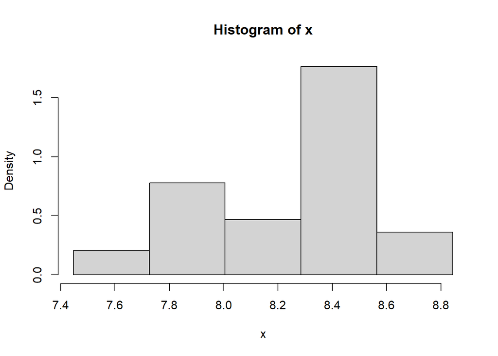

```r
nbr_opt <- 5
hx <- hist(x,breaks=seq(A,Z,length=nbr_opt+1),freq=F)
```

#### 6.

Very similarly as the previous experiment, optimal kernel density estimator bandwidth is chosen. This time by directly varying bin width b instead of the amount of bins.

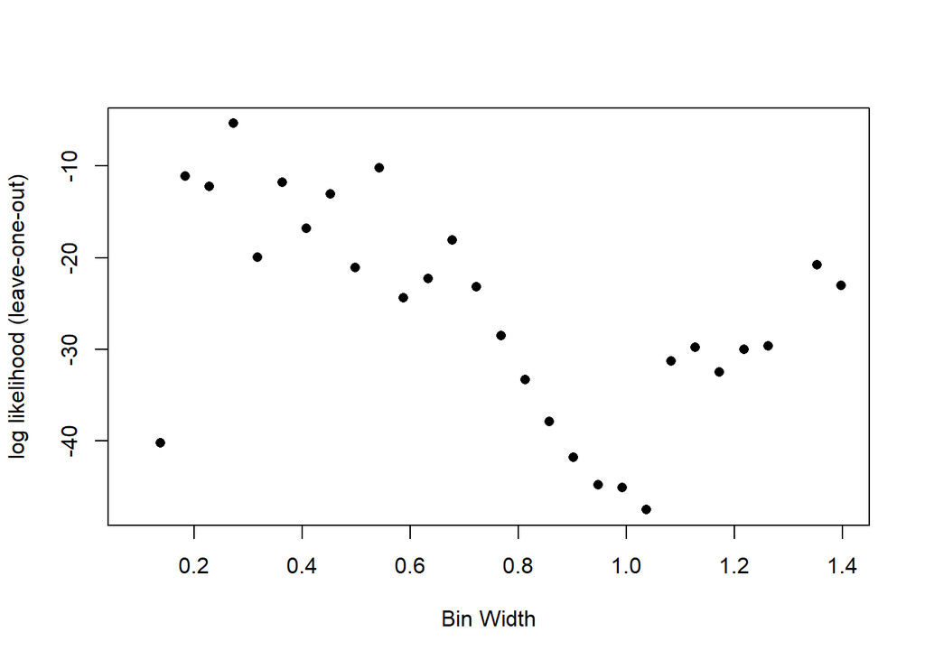

```r
b_seq <- seq((Z-A)/15,(Z-A)/1,length=30)
b_loo_log_likelihood <- c()
for (b in b_seq) {
  hx <- hist(x,breaks=seq(A,Z+b,by=b), plot=F)
  hx_f <- stepfun(hx$breaks,c(0,hx$density,0))
  y_hist <- hx_f(x)
  y_loo_hist <- (y_hist-(1/(length(x)*b)))*(length(x)/(length(x)-1))
  if (any(y_loo_hist==0)) {
    b_loo_log_likelihood <- c(b_loo_log_likelihood,-Inf)
  }
  else {
    b_loo_log_likelihood <- c(b_loo_log_likelihood,sum(log(y_loo_hist)))
  }
}
plot(b_seq,b_loo_log_likelihood, pch=16, xlab='Bin Width', ylab = 'log likelihood (leave-one-out)')
```

```r
b_optimal <- b_seq[which.max(b_loo_log_likelihood)]
```

From the bin-width vs. log-likelihood plot it becomes clear that the optimal value for the bin width (of the proposed sequence) is 0.272977. The corresponding histogram is as follows:

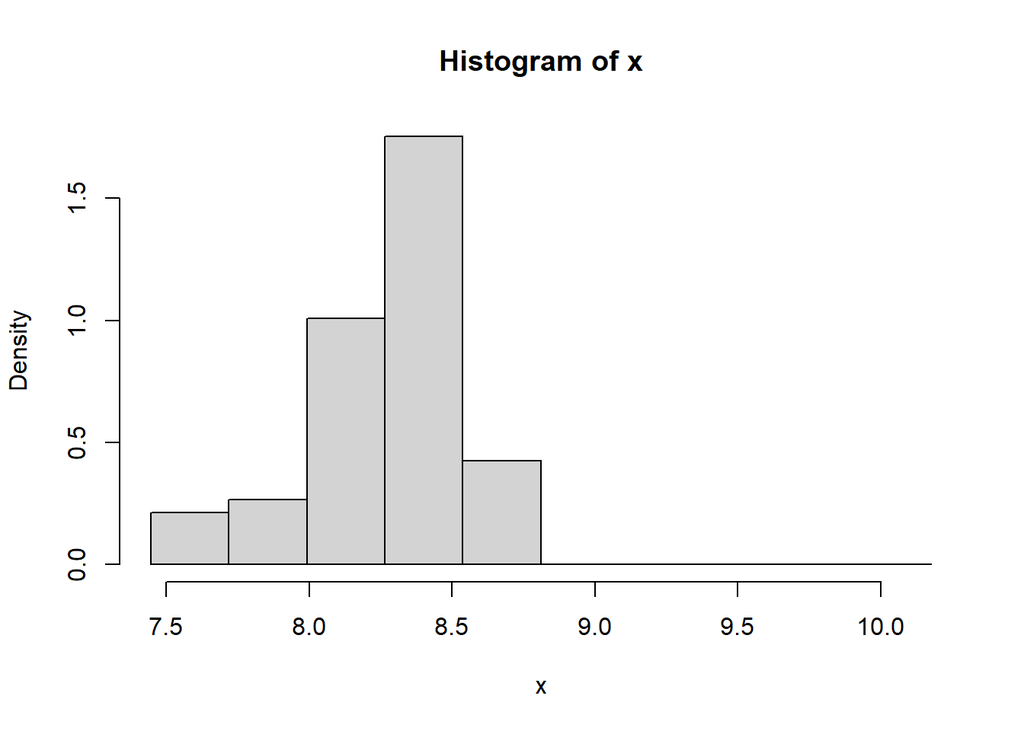

```r
hx <- hist(x,breaks=seq(A,Z+b,by=b_optimal), plot=F)
plot(hx,freq = FALSE)
```

#### 7.

Generate $n=100$ data from
$$f(x) = (3/4)N(x; m = 0, s = 1) +(1/4) N(x; m = 3/2, s =
1/3)$$

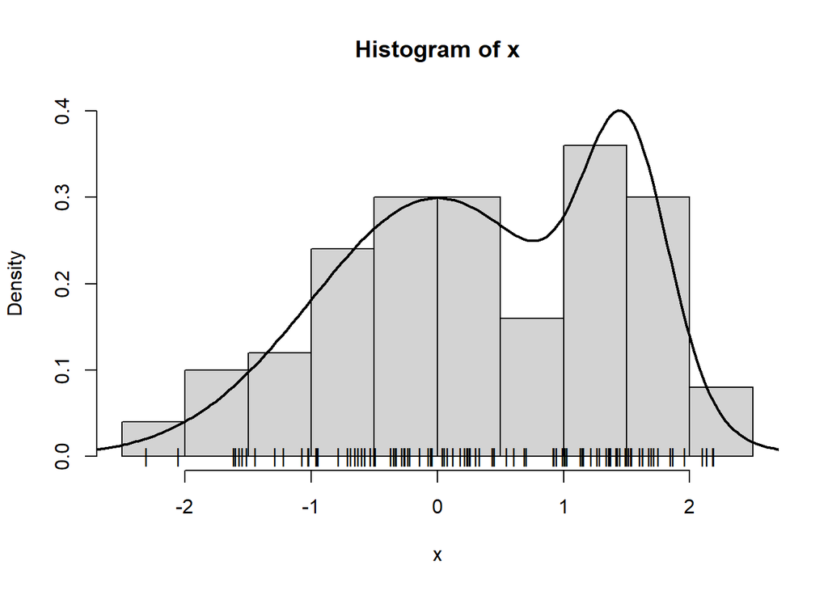

```r
set.seed(123)
n <- 100
mu <- c(0,3/2)
sigma <- c(1,1/3)
alpha <- c(3/4,1/4)
x <- sim.mixt(n=n, k=2, mu=mu, sigma=sigma, alpha=alpha, gr=T)
points(x,0*x,pch="|")
```

```r
sigma.mixt <- 1.095287
b_scott <- 3.49 * sigma.mixt * length(x)^(-1/3)
```

First we use the Scott’s formula to find a proposed value of b = 0.8235438 (calculations for this value can be found in `density_estimation.Rmd`). The corresponding histogram is as follows:

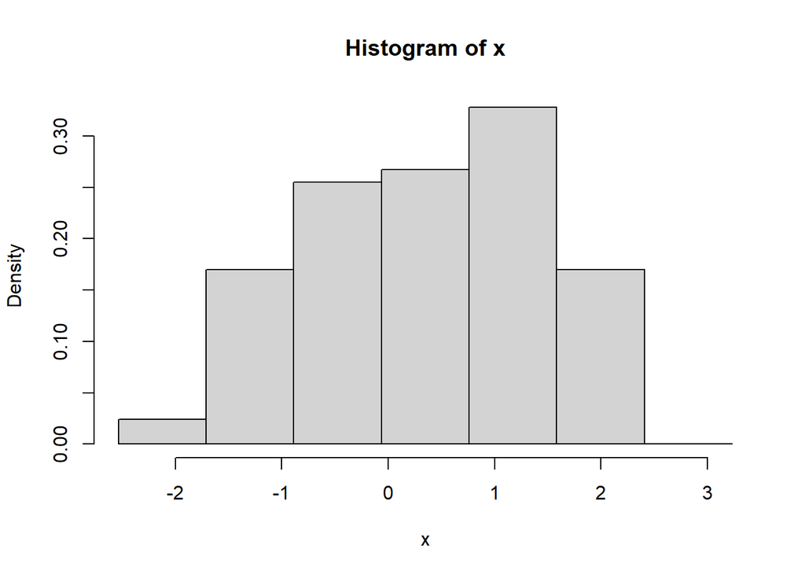

```r
A <- min(x)-.05*diff(range(x))
Z <- max(x)+.05*diff(range(x))

hx <- hist(x,breaks=seq(A,Z+b,by=b_scott), plot=F)
plot(hx,freq = FALSE)
```

Now the Max-likelihood method is used. To consider a varied amount of proposals for b, the sequence of proposed b-values to select from is varied from 0.05 to 1.75 in steps of 0.01.

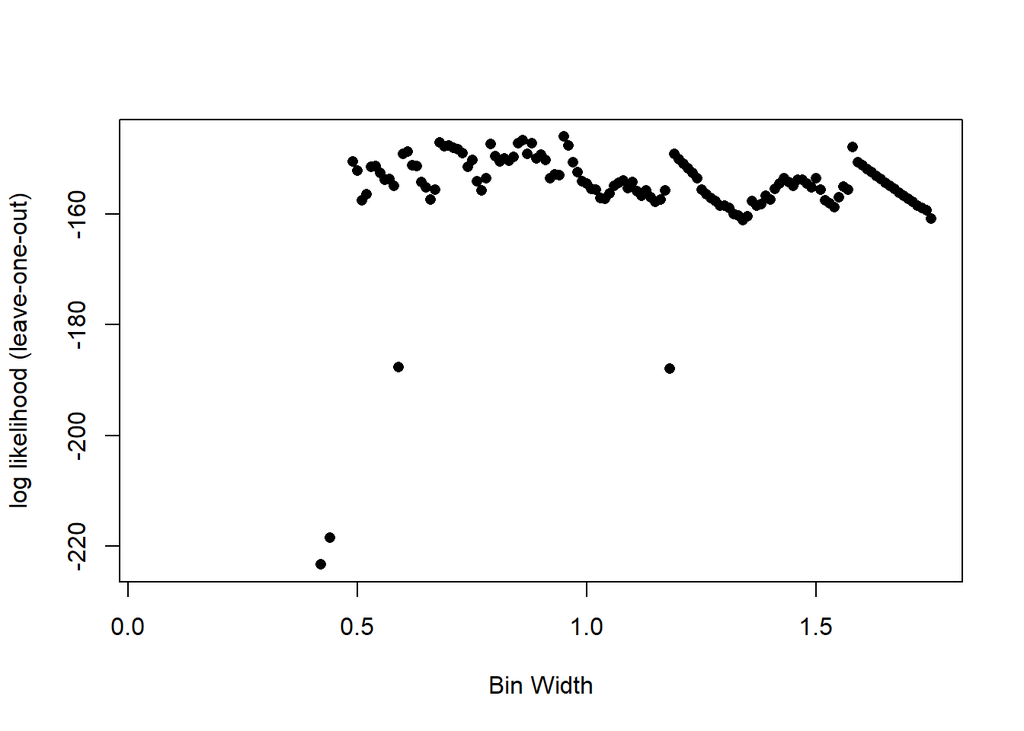

```r
b_seq = seq(0.05, 1.75, by=0.01)
b_loo_log_likelihood <- c()

for (b in b_seq) {
  hx <- hist(x,breaks=seq(A,Z+b,by=b), plot=F)
  hx_f <- stepfun(hx$breaks,c(0,hx$density,0))
  y_hist <- hx_f(x)
  y_loo_hist <- (y_hist-(1/(length(x)*b)))*(length(x)/(length(x)-1))
  if (any(y_loo_hist<=0)) {
    b_loo_log_likelihood <- c(b_loo_log_likelihood,-Inf)
  }
  else {
    b_loo_log_likelihood <- c(b_loo_log_likelihood,sum(log(y_loo_hist)))
  }
}
plot(b_seq,b_loo_log_likelihood, pch=16, xlab='Bin Width', ylab = 'log likelihood (leave-one-out)')
```

```r
b_ml <- b_seq[which.max(b_loo_log_likelihood)]
```

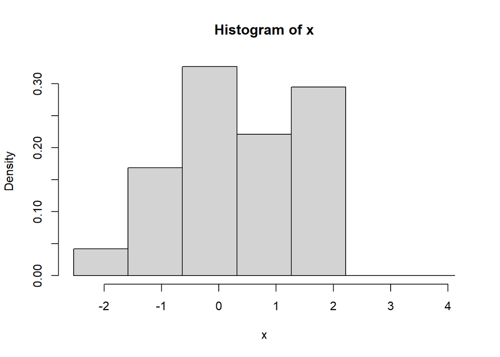

```r
hx <- hist(x,breaks=seq(A,Z+b,by=b_ml), plot=F)
plot(hx,freq = FALSE)
```

The two proposed values for b are substantially different. The corresponding histograms/kernel density estimators clearly show the difference the choice of b makes: the corresponding patterns seem to give quite a different view on the data. Using Scott’s formula, the mixture of two distributions (here gaussians) is not at all clearly visible, while the max-likelihood method’s bin width seems to highlight more the presence of two distinct patterns.

#### 8.

In this exercise, the *gaussian* kernel is used and its bandwidth found similarly to the bin width in the previous exercises. A wide range of bandwidth values are proposed (from 0.1 to 1 with steps of 0.01) and the a plot of each leave-one-out log-likelihood provided.

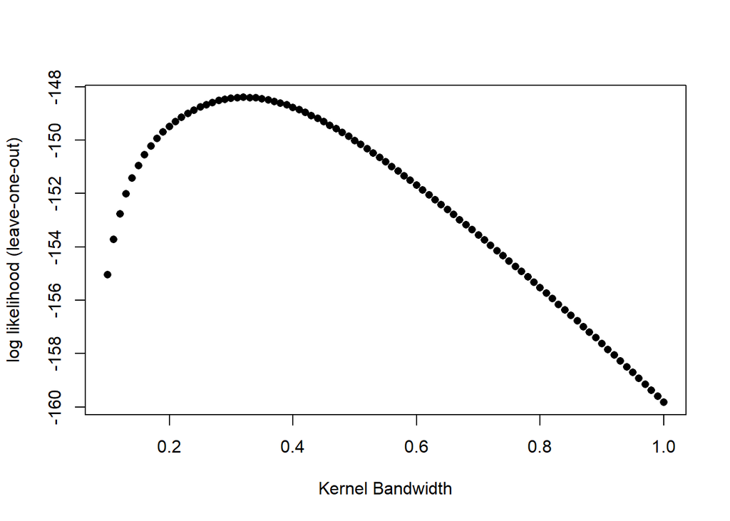

```r
h_seq <- seq(0.1,1, by=0.01)
h_loo_log_likelihood <- c()

for (h in h_seq) {
  kx <- density(x,bw=h,kernel='gaussian')
  kx_f <- approxfun(x=kx$x, y=kx$y, method='linear', rule=2)
  y_density <- kx_f(x)
  y_loo_density <- (y_density-(1/(sqrt(2*pi)*length(x)*h)))*(length(x)/(length(x)-1))

    h_loo_log_likelihood <- c(h_loo_log_likelihood,sum(log(y_loo_density)))
}

plot(h_seq,h_loo_log_likelihood, pch=16, xlab='Kernel Bandwidth', ylab = 'log likelihood (leave-one-out)')
```

```r
h_ml <- h_seq[which.max(h_loo_log_likelihood)]
```

From this experiment, it becomes clear that the optimal max likelihood value for h is 0.32. The corresponding density function is plotted below.

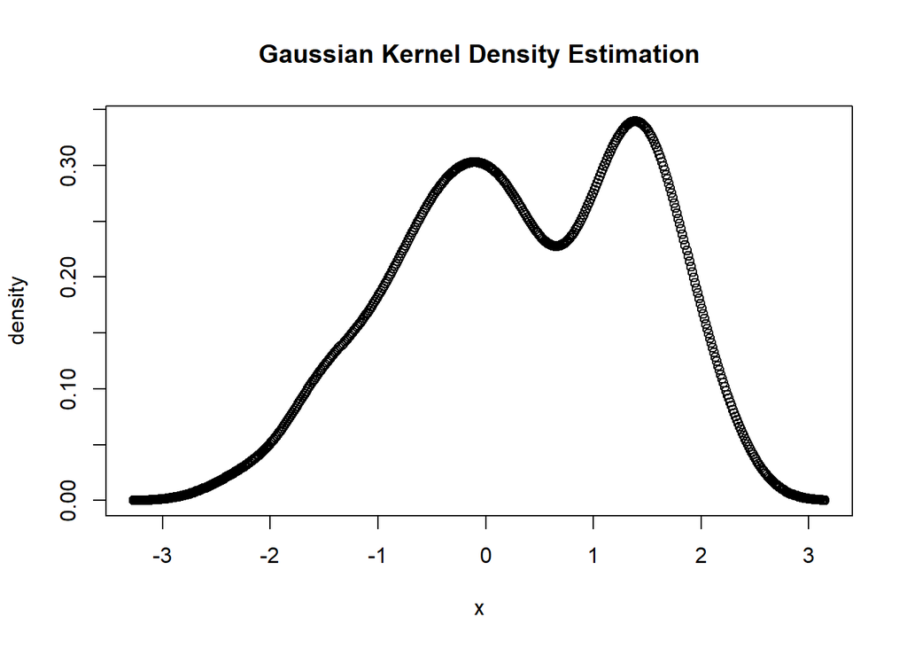

```r
kx <- density(x,bw=h_ml,kernel='gaussian')
kx_f <- approxfun(x=kx$x, y=kx$y, method='linear', rule=2)
plot(kx$x, kx$y, xlab='x', ylab = 'density', main = 'Gaussian Kernel Density Estimation')
```